# Estudis d'Informàtica, Multimedia i Telecomunicacions

# Mineria de dades: PRA2 - Projecte de mineria de dades

Autor: Octavi Bassegoda

Juny 2026

# 1 Enunciat

Com a continuació de l’estudi iniciat a la Pràctica 1, procedim a **aplicar models analítics, tant no supervisats com supervisats**, sobre el joc de dades seleccionat i preparat. En aquesta **Pràctica 2 haureu de carregar les dades prèviament preparades a la Pràctica 1**.

L’objectiu és que poseu en pràctica amb les vostres pròpies dades tots els models no supervisats i supervisats que s’han utilitzat a les 3 PACs prèvies. A més, es proposa que s’utilitzin mètriques i algorismes alternatius als proposats a les PACs ja realitzades.

**Punt comú per a tots els exercicis**

En tots els apartats dels exercicis d’aquesta pràctica es demana a l’estudiant, a més d’aplicar els diferents mètodes, analitzar correctament el problema, **detallar-ho de manera exhaustiva**, ressaltant el perquè i com s’ha realitzat, incloure elements visuals, explicar els resultats i fer les comparatives oportunes amb les seves conclusions.

Per a tota la pràctica és **necessari documentar** cada apartat de l’exercici pràctic que s’ha fet, el perquè s’ha fet i com s’ha fet. Així mateix, totes les decisions i conclusions hauran de ser presentades de forma raonada i clara, **contextualitzant els resultats**, és a dir, especificant tots i cadascun dels passos que s’hagin dut a terme per resoldre’ls.

D’aquesta manera es demana a l’estudiant que completi els passos següents amb el joc de dades preparat a la Practica 1:

**Models no supervisats**

1. Aplicar l’algorisme **no supervisat** *k-means* basat en el concepte de distància entre les mitjanes dels grups, sobre el joc de dades originals i les dades normalitzades. Es recorda que cal utilitzar les variables quantitatives o binàries que formin part de la base de dades. També, en aquest apartat cal decidir si els grups es defineixen a partir de les variables normalitzades o no i cal seleccionar el nombre de clústers que millor s’ajusti a les dades.
2. Utilitzant el nombre de clústers i les dades (normalitzades o no) seleccionades al punt 1, utilitzar l’algorisme *k-medians* (basat en les medianes com a centres dels clústers) per definir cadascun dels grups. Compareu els resultats obtinguts amb ambdós algorismes, *k-means* i *k-medians*, i comenteu quin mètode us sembla el més adequat per a les vostres dades. Tingueu en compte que l’algorisme basat en la mediana no és el mateix que l’*around medoids*, que s’implementa amb la funció `pam()` del paquet “cluster” de R. Per tant, addicionalment també podeu comparar els resultats amb els obtinguts amb el mètode *around medoids*.
3. Entrenar de nou el model basat en *k-means* que heu seleccionat al punt 1 però usant una **mètrica de distància diferent a la distància euclidiana** i compareu els resultats.
4. Utilitzar els algorismes **DBSCAN** y **OPTICS**, provant amb diferents valors del paràmetre `eps` i `minPts`, i comparar els resultats amb els mètodes anteriors. Comenteu si el nombre de clústers coincideix amb el punt 1 i si els casos que els formen són similars.

**Models supervisats**

5. Seleccionar una mostra d’entrenament i una de test utilitzant les proporcions que es considerin més adequades en funció de la disponibilitat de dades. Justificar aquesta selecció.
6. Un cop definida la variable objecte que es vol predir, aplicar un model de generació de regles a partir de **arbres de decisió** i ajustar les diferents opcions (mida mínima dels nodes, criteris de divisió, …) per al seu entrenament. Obtenir l’arbre sense i amb opcions de poda. Obtenir la matriu de confusió. Finalment, comparar els resultats obtinguts amb opcions de poda i sense. Alternativament, si la variable objecte destudi és quantitativa pura sobtenen els criteris d’error que ens permetin determinar la capacitat predictiva.
7. Aplicar un **model supervisat** diferent del punt 6 (pot ser un algorisme d’arbres de decisió diferent o un altre algorisme supervisat alternatiu). Compareu el resultat amb el model generat anteriorment. Es poden utilitzar els criteris d’avaluació de models descrits al material docent de l’assignatura.

**Limitacions i conclusions finals**

8. Identificar possibles **limitacions** del conjunt de dades seleccionat i **analitzar els riscos** en cas d’utilitzar els models entrenats per classificar un nou cas. Per exemple, en els models supervisats poden aparèixer dificultats de sobreajustament; en el cas de la classificació, els percentatges de falsos positius i falsos negatius poden ser similars, etc.. Resum de les **principals conclusions** obtingudes dels models no supervisats i supervisats.

**Interacció amb la IA**

9. Utilitzar la IA per aprofundir en la reflexió sobre els models apresos, els resultats obtinguts i les seves possibles millores. Per exemple, en el cas dels models no supervisats, es podria plantejar, entre altres, si és adequat emprar distàncies diferents de l’euclídia, en quins contextos serien més convenients i quines alternatives existeixen. Pel que fa als models supervisats, seria pertinent analitzar amb més detall quins tipus d’errors cometen els models entrenats i explorar possibles alternatives que permetin millorar els resultats assolits.

**NOTA IMPORTANT:** *Recordeu que si les variables a la vostra base de dades tenen unitats de mesura molt diferents és recomanable transformar les variables per evitar l’efecte d’escala derivat d’aquestes unitats de mesura.*

# 2 RESPOSTES

## 2.1 Descripció del joc de dades

El joc de dades `clinical_clean.csv` prové de **VitalDB**, un repositori d’alta fidelitat de senyals vitals i dades clíniques de pacients quirúrgics de l’Hospital Universitari Nacional de Seül. Cada fila correspon a una **cirurgia** i recull informació del pacient, de l’acte quirúrgic i del seu desenllaç. La versió que emprem aquí és la que es va netejar i preparar a la **Pràctica 1** (5.926 casos i 78 variables).

### 2.1.1 Glossari de variables explicat per a no especialistes

A continuació es resumeix, en termes entenedors per a una audiència no mèdica igual que vàrem fer a la PRAC1, què representa cada variable del fitxer `clinical_clean.csv`. La descripció s’ha elaborat a partir del diccionari oficial de VitalDB i del paper de referència del dataset (Lee et al., *Scientific Data*, 2022).

**Identificadors i temps del cas (registre de la cirurgia):**

- **caseid**: identificador anònim del cas (cada fila = una cirurgia).
- **subjectid**: identificador anònim del pacient. Un mateix pacient pot aparèixer en més d’un cas si ha estat operat diverses vegades.
- **casestart / caseend**: instant d’inici i fi de l’enregistrament del cas, en segons. `casestart` es fixa a 0 per anonimització.
- **anestart / aneend**: instant d’inici i fi de l’**anestèsia**, en segons des de `casestart`.
- **opstart / opend**: instant d’inici i fi de la **cirurgia** pròpiament dita (sol estar dins de la finestra d’anestèsia).
- **adm / dis**: instants d’**admissió** a l’hospital i **alta** del pacient, en segons des de `casestart` (poden ser negatius si l’admissió és anterior a l’inici del cas).

**Variables de resultat (outcomes — el que volem predir):**

- **icu_days**: dies que el pacient ha passat a la **UCI** després de la cirurgia (0 si no hi ha ingressat).
- **death_inhosp**: 1 si el pacient mor durant l’ingrés hospitalari, 0 altrament. És una de les variables de resultat candidates per a l’anàlisi supervisat.

**Dades demogràfiques i estat general del pacient:**

- **age**: edat en anys.
- **sex**: sexe (`M` masculí / `F` femení).
- **height / weight**: alçada (cm) i pes (kg).
- **bmi**: índex de massa corporal (pes/alçada²), un indicador d’obesitat.
- **asa**: classificació **ASA** de l’estat físic preoperatori (Societat Americana d’Anestesiologia). Va de 1 (pacient sa) a 6 (donant d’òrgans en mort cerebral); a la pràctica clínica es fa servir habitualment d’1 a 5 i és un dels millors predictors de risc quirúrgic.
- **emop**: 1 si la cirurgia és d’**urgència**, 0 si és programada.

**Tipus de cirurgia i posicionament del pacient:**

- **department**: departament quirúrgic responsable (cirurgia general, toràcica, urològica, ginecològica…).
- **optype**: categoria àmplia del tipus de cirurgia (per exemple Colorectal, Stomach, Hepatic…).
- **dx**: diagnòstic principal que motiva la cirurgia (text lliure).
- **opname**: nom específic de la intervenció (text lliure).
- **approach**: via d’abordatge: **oberta** (cirurgia tradicional), **laparoscòpica** o **robòtica** (mínimament invasives).
- **position**: postura del pacient a la taula d’operacions (decúbit supí, lateral, litotomia…).
- **ane_type**: tipus d’anestèsia (general, regional, sedació, etc.).

**Antecedents i estudis preoperatoris (estat clínic abans d’operar):**

- **preop_htn**: 1 si el pacient té **hipertensió** prèvia.
- **preop_dm**: 1 si té **diabetis** prèvia.
- **preop_ecg**: troballa de l’**electrocardiograma** preoperatori (ritme sinusal normal, arrítmia, etc.).
- **preop_pft**: resultat de la **prova de funció pulmonar** preoperatòria (normal, restrictiva, obstructiva…).

**Analítica de sang preoperatòria** (mesures rutinàries abans de la cirurgia; valors fora de rang indiquen problemes mèdics):

- **preop_hb**: **hemoglobina** (g/dL). Valors baixos = anèmia.
- **preop_plt**: recompte de **plaquetes** (x1000/µL). Crucial per la coagulació.
- **preop_pt**: **temps de protrombina** (%). Mesura de coagulació.
- **preop_aptt**: **temps de tromboplastina parcial activada** (s). Una altra mesura de coagulació.
- **preop_na**: **sodi** sèric (mmol/L).
- **preop_k**: **potassi** sèric (mmol/L).
- **preop_gluc**: **glucosa** en sang (mg/dL).
- **preop_alb**: **albúmina** (g/dL). Marcador de nutrició i estat general.
- **preop_ast** (GOT) i **preop_alt** (GPT): enzims hepàtics (UI/L). Valors elevats = lesió hepàtica.
- **preop_bun**: **urea** en sang (mg/dL). Indicador de funció renal.
- **preop_cr**: **creatinina** sèrica (mg/dL). Marcador clau de funció renal.

**Gasometria arterial preoperatòria** (oxigenació i equilibri àcid-base):

- **preop_ph**: pH de la sang arterial.
- **preop_hco3**: bicarbonat (mmol/L).
- **preop_be**: excés de bases (mmol/L).
- **preop_pao2**: pressió parcial d’**oxigen** arterial (mmHg).
- **preop_paco2**: pressió parcial de **CO₂** arterial (mmHg).
- **preop_sao2**: saturació d’oxigen arterial (%).

**Maneig de la via aèria i tubs d’anestèsia:**

- **cormack**: classificació de **Cormack-Lehane**, dificultat per veure la glotis durant la intubació (I = fàcil, IV = molt difícil).
- **airway**: via per la qual es ventila el pacient (oral, nasal, etc.).
- **tubesize**: diàmetre del tub endotraqueal (mm).
- **dltubesize**: mida del tub de **doble llum** (Fr) si cal aïllar un pulmó (cirurgia toràcica).
- **lmasize**: mida de la **màscara laríngia** si s’usa en lloc del tub.

**Vies vasculars** (zones del cos on s’han col·locat catèters):

- **iv1, iv2**: lloc de la primera i segona via **intravenosa perifèrica** (per administrar fluids i medicació).
- **aline1, aline2**: lloc de la primera i segona **línia arterial** (mesurar la tensió en directe i extreure gasometries).
- **cline1, cline2**: lloc del primer i segon **catèter venós central** (cirurgies grans o pacients crítics).

**Esdeveniments intraoperatoris** (què passa durant la cirurgia):

- **intraop_ebl**: pèrdua de sang estimada (mL).
- **intraop_uo**: volum d’**orina** durant la cirurgia (mL); marcador indirecte de perfusió renal.
- **intraop_rbc**: unitats de **concentrats d’hematies** transfosos.
- **intraop_ffp**: unitats de **plasma fresc congelat** transfosos.
- **intraop_crystalloid**: volum total de sèrum (cristal·loides) infós (mL).
- **intraop_colloid**: volum de **col·loides** (expansors de plasma) en mL.

**Fàrmacs anestèsics i de suport hemodinàmic administrats durant la cirurgia:**

- **intraop_ppf**: **propofol** en bolus (mg). Anestèsic intravenós.
- **intraop_mdz**: **midazolam** (mg). Sedant.
- **intraop_ftn**: **fentanil** (µg). Analgèsic opioide potent.
- **intraop_rocu**: **rocuroni** (mg). Bloquejador neuromuscular.
- **intraop_vecu**: **vecuroni** (mg). Bloquejador neuromuscular.
- **intraop_eph**: **efedrina** (mg). Vasopressor (puja la tensió).
- **intraop_phe**: **fenilefrina** (µg). Vasopressor.
- **intraop_epi**: **adrenalina** (µg). Vasopressor potent en hipotensió greu o aturada.
- **intraop_ca**: **clorur de calci** (mg). Reposició electrolítica i suport contràctil cardíac.

**Variables derivades a la Pràctica 1** (no figuren al diccionari original; es van calcular durant la preparació de les dades):

- **icu_admission**: indicador `No/Sí` d’ingrés a la **UCI** després de la cirurgia (derivat de `icu_days > 0`). És la **variable objectiu** que predirem als exercicis supervisats (5–7); s’ha triat per davant de `death_inhosp` perquè aquesta última és molt minoritària (≈ 0,8 % de casos) i faria que un classificador trivial ja encertés gairebé sempre.
- **op_duration_min**: durada de la **cirurgia** en minuts (`opend − opstart`).
- **ane_duration_min**: durada de l’**anestèsia** en minuts (`aneend − anestart`).
- **los_hosp_days**: durada de l’**estada hospitalària** en dies (*length of stay*).

> *Font:* Lee, H.-C., Park, Y., Yoon, S. B., Yang, S. M., Park, D., & Jung, C.-W. (2022). *VitalDB, a high-fidelity multi-parameter vital signs database in surgical patients*. **Scientific Data**, 9, 279. Diccionari oficial: `clinical_parameters.csv` del dataset.

## 2.2 Preparació de les dades (comuna als exercicis 1–4)

Carreguem el joc de dades net generat a la Pràctica 1 i construïm la matriu de treball per als models **no supervisats**. L’enunciat indica que cal emprar únicament **variables quantitatives o binàries**; per tant descartem:

- **Identificadors i marques de temps** (`caseid`, `subjectid`, `casestart`, `opstart`, …): no aporten informació de perfil clínic.
- **Variables categòriques de text** (`department`, `optype`, `dx`, `opname`, `approach`, …): no són mètriques i no entren en una distància euclidiana.
- **Variables de resultat** (*outcomes*: `icu_admission`, `death_inhosp`, `los_hosp_days`, `icu_days`, `op_duration_min`): les reservem per als models supervisats (exercicis 5–7), de manera que l’agrupament descrigui el **perfil del pacient i de la intervenció**, no el seu desenllaç.

Les variables binàries `No/Sí` (`emop`, `preop_htn`, `preop_dm`) es recodifiquen a `0/1` per poder-les tractar numèricament.

```r
dades <- read.csv("clinical_clean.csv", stringsAsFactors = FALSE)

# Recodifiquem els indicadors binaris No/Sí a 0/1
bin_flags <- c("emop", "preop_htn", "preop_dm")
for (b in bin_flags) dades[[b]] <- ifelse(dades[[b]] == "Sí", 1L, 0L)

# Columnes excloses: identificadors, marques de temps i variables de resultat
excloses <- c("caseid", "subjectid", "casestart", "caseend", "anestart",
              "aneend", "opstart", "opend", "adm", "dis", "icu_days",
              "op_duration_min", "ane_duration_min", "los_hosp_days",
              "death_inhosp", "icu_admission")

num_cols <- names(dades)[sapply(dades, is.numeric)]
candidates <- setdiff(union(num_cols, bin_flags), excloses)
```

Diverses variables tenen una proporció elevada de valors absents (les gasometries preoperatòries superen el 90 %). Com que l’agrupament treballa amb **casos complets**, hi ha un compromís entre *nombre de variables* i *nombre de casos*. Provem diferents llindars de valors absents:

```r
llindars <- c(0.40, 0.25, 0.20, 0.10, 0.05)
taula <- sapply(llindars, function(thr) {
  f <- candidates[colMeans(is.na(dades[candidates])) <= thr]
  c(variables = length(f), casos = sum(complete.cases(dades[f])))
})
colnames(taula) <- paste0("≤", llindars * 100, "%")
taula
```

```
##           ≤40% ≤25% ≤20% ≤10%  ≤5%
## variables   35   34   33   33   32
## casos     2833 4145 5249 5249 5605
```

Un llindar del **20 %** és el punt d’equilibri: conserva **33 variables** i **5.249 casos** (≈ 89 % de les files), descartant només `intraop_ebl` i `tubesize` —les dues variables que més files eliminaven— respecte del llindar del 40 %. Fixem aquest criteri i construïm la matriu de treball, amb la versió **original** i la **normalitzada** (centrada i escalada amb *z-score*):

```r
vars_model <- candidates[colMeans(is.na(dades[candidates])) <= 0.20]
X  <- dades[vars_model]
X  <- X[complete.cases(X), ]   # 5.249 casos complets
Xs <- scale(X)                  # versió normalitzada (z-score)

dim(X)
```

```
## [1] 5249   33
```

```r
vars_model
```

```
##  [1] "age"                 "height"              "weight"
##  [4] "bmi"                 "asa"                 "emop"
##  [7] "preop_htn"           "preop_dm"            "preop_hb"
## [10] "preop_plt"           "preop_pt"            "preop_aptt"
## [13] "preop_na"            "preop_k"             "preop_gluc"
## [16] "preop_alb"           "preop_ast"           "preop_alt"
## [19] "preop_bun"           "preop_cr"            "intraop_rbc"
## [22] "intraop_ffp"         "intraop_crystalloid" "intraop_colloid"
## [25] "intraop_ppf"         "intraop_mdz"         "intraop_ftn"
## [28] "intraop_rocu"        "intraop_vecu"        "intraop_eph"
## [31] "intraop_phe"         "intraop_epi"         "intraop_ca"
```

Com veiem son 33 variables totes que tenen a veure amb paràmetres preoperatoris com l’edat o el bmi o analítiques preoperatòries; o bé amb paràmetres intra- operatoris. Això ens servirà més endavant per fer predicció sobre outcomes postoperatoris en els exercisis 5-7. ***

## 2.3 Exercici 1 (20%)

### 2.3.1 S’obté l’agrupació mitjançant k-means amb les dades originals i normalitzades.

Apliquem *k-means* sobre les dues versions de la matriu. Abans, però, cal decidir el **nombre de clústers** *k*. Fem servir dos diagnòstics complementaris sobre les dades **normalitzades**: el mètode del **colze** (suma de quadrats intra-clúster, *WSS*) i el **coeficient de silueta** mitjà.

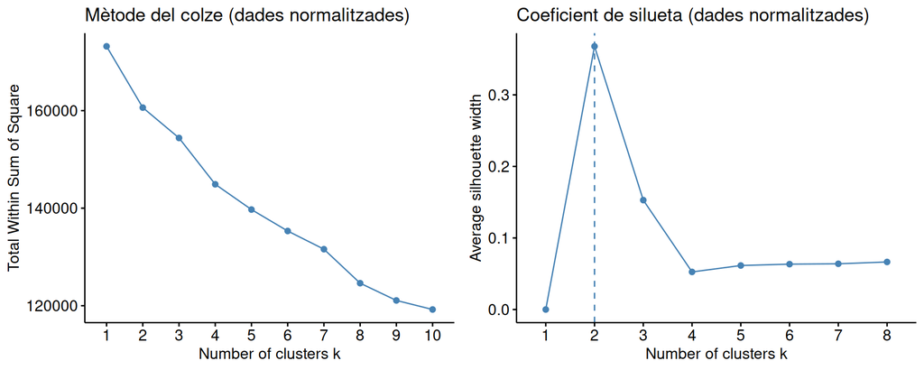

```r
set.seed(42)
g_wss <- fviz_nbclust(Xs, kmeans, method = "wss", k.max = 10) +
  labs(title = "Mètode del colze (dades normalitzades)")
g_sil <- fviz_nbclust(Xs, kmeans, method = "silhouette", k.max = 8) +
  labs(title = "Coeficient de silueta (dades normalitzades)")
gridExtra::grid.arrange(g_wss, g_sil, ncol = 2)
```

Ajustem ara *k-means* amb k = 2 sobre les **dues** versions de les dades per comparar l’efecte de l’escala:

```r
set.seed(42)
km_raw <- kmeans(X,  centers = 2, nstart = 25, iter.max = 50)  # dades originals
km_std <- kmeans(Xs, centers = 2, nstart = 25, iter.max = 50)  # dades normalitzades
```

### 2.3.2 S’analitzen, mostren i comenten les mesures de qualitat del model generat.

Comparem la qualitat dels dos models amb la silueta mitjana (sobre tots els casos complets) i la proporció de variància explicada (`betweenss/totss`):

```r
sil_raw <- mean(silhouette(kmeans(X,  2, nstart = 25)$cluster, dist(X))[, 3])
sil_std <- mean(silhouette(kmeans(Xs, 2, nstart = 25)$cluster, dist(Xs))[, 3])

data.frame(
  Model               = c("Dades originals", "Dades normalitzades"),
  Silueta_mitjana     = round(c(sil_raw, sil_std), 3),
  Variancia_explicada = round(c(km_raw$betweenss / km_raw$totss,
                                km_std$betweenss / km_std$totss), 3),
  Mides               = c(paste(km_raw$size, collapse = " / "),
                          paste(km_std$size, collapse = " / "))
)
```

```
##                 Model Silueta_mitjana Variancia_explicada      Mides
## 1     Dades originals           0.728               0.413 4747 / 502
## 2 Dades normalitzades           0.370               0.073 685 / 4564
```

Aparentment les **dades originals** donen una silueta més alta (≈ 0,73 enfront de ≈ 0,37). Aquesta xifra, però, és **enganyosa**: en absència d’escala, la distància euclidiana queda dominada per les variables de magnitud més gran —sobretot `intraop_crystalloid`, expressada en mil·lilitres (ordres de milers)— i per les variables de transfusió. L’agrupament resultant separa essencialment *volum de fluïdoteràpia*, no un **perfil clínic integral**. Aquest és exactament l’efecte d’escala que adverteix l’enunciat. Per això **seleccionem el model amb les dades normalitzades**, on totes les variables hi contribueixen per igual.

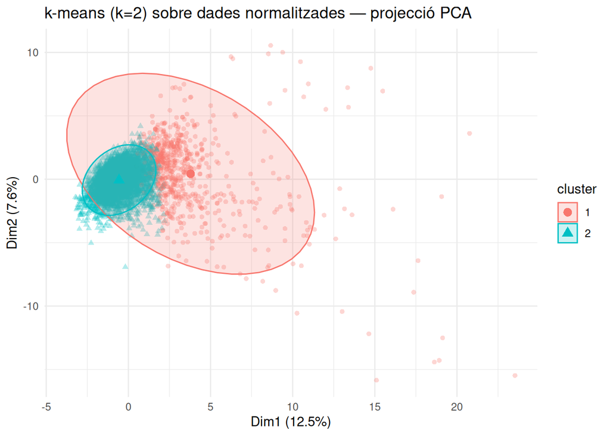

```r
fviz_cluster(km_std, data = Xs, geom = "point", alpha = 0.3,
             ellipse.type = "norm",
             main = "k-means (k=2) sobre dades normalitzades — projecció PCA") +
  theme_minimal()
```

La projecció sobre les dues primeres components principals mostra un grup gran i compacte i un grup menor i més dispers. La variància explicada és baixa (`betweenss/totss` ≈ 0,07): k-means captura poca separació global, coherent amb una estructura de tipus gradient. Tot i així la silueta (0,37) i, sobretot, la **interpretabilitat clínica** dels grups (apartat següent) justifiquen la solució.

### 2.3.3 S’interpreten els centres, la mida dels grups i la seva dispersió.

Recuperem els centres en **escala original** (mitjana de cada variable per grup) per fer-los interpretables clínicament, i la dispersió intra-grup:

```r
grup <- km_std$cluster
centres <- aggregate(X, list(Grup = grup), mean)
destacades <- c("age", "bmi", "asa", "emop", "preop_htn", "preop_hb",
                "preop_alb", "preop_cr", "intraop_crystalloid",
                "intraop_rbc", "intraop_ftn")
round(t(centres[, destacades]), 2)
```

```
##                        [,1]   [,2]
## age                   57.23  57.62
## bmi                   21.24  23.59
## asa                    2.54   1.74
## emop                   0.39   0.07
## preop_htn              0.45   0.29
## preop_hb              10.55  13.18
## preop_alb              3.36   4.17
## preop_cr               2.90   0.82
## intraop_crystalloid 2356.29 852.95
## intraop_rbc            3.54   0.04
## intraop_ftn           19.16  16.82
```

```r
# Mida dels grups i dispersió (WSS per grup / nombre de casos)
data.frame(
  Grup       = 1:2,
  Mida       = km_std$size,
  Percentatge= round(100 * km_std$size / sum(km_std$size), 1),
  WSS        = round(km_std$withinss),
  WSS_per_cas= round(km_std$withinss / km_std$size, 2)
)
```

```
##   Grup Mida Percentatge   WSS WSS_per_cas
## 1    1  685        13.1 74857      109.28
## 2    2 4564        86.9 85764       18.79
```

**Interpretació dels grups:**

- **Grup 1 (≈ 685 casos, 13 %) — pacients d’alt risc / comòrbids.** Presenten un *ASA* més alt (≈ 2,5), una proporció molt superior de **cirurgia urgent** (`emop` ≈ 0,39 enfront de 0,07) i d’**hipertensió**, una **hemoglobina** preoperatòria més baixa (≈ 10,6) i **albúmina** baixa (≈ 3,4) —signe de pitjor estat nutricional—, i una **creatinina** clarament elevada (≈ 2,9, indici d’insuficiència renal). Intraoperatòriament reben molt més **cristal·loide** (≈ 2,4 L) i més transfusió. Això vol dir que han sagnat més durant la cirurgia probablement. És el grup amb **major dispersió** (WSS per cas més alt), reflex de la seva heterogeneïtat clínica.
- **Grup 2 (≈ 4.564 casos, 87 %) — pacients d’estàndard de risc.** *ASA* ≈ 1,75, poca cirurgia urgent, **analítica preoperatòria dins de la normalitat** (hemoglobina ≈ 13,2, albúmina ≈ 4,2, creatinina ≈ 0,8) i menor necessitat de fluïdoteràpia. És un grup gran, compacte i homogeni.

En síntesi, *k-means* amb dades normalitzades i k = 2 identifica una partició clínicament rellevant: **pacient quirúrgic complex/fràgil** enfront de **pacient quirúrgic estàndard**. Aquesta agrupació servirà de referència per comparar-la amb *k-medians* (exercici 2), una mètrica no euclidiana (exercici 3) i els mètodes basats en densitat (exercici 4).

> *Documentació dels paquets emprats: `kmeans` (paquet base `stats`) — https://stat.ethz.ch/R-manual/R-devel/library/stats/html/kmeans.html; `factoextra` (diagnòstic i visualització de clústers) — https://CRAN.R-project.org/package=factoextra; `cluster` (coeficient de silueta) — https://CRAN.R-project.org/package=cluster.*

## 2.4 Exercici 2 (10%)

### 2.4.1 S’obté l’agrupació k-medians amb el nombre de grups seleccionat a l’exercici 1 (de manera opcional, també es pot obtenir l’agrupament mitjançant el mètode *around medoids*).

A diferència de *k-means* —que situa el centre de cada grup a la **mitjana** i mesura distàncies amb la mètrica **euclidiana** (L2)—, *k-medians* col·loca el centre a la **mediana** de cada variable i treballa amb la distància **Manhattan** (L1, suma de diferències absolutes). El canvi té una conseqüència directa: la mediana és **robusta als valors extrems**. Un grapat de pacients amb una creatinina molt elevada arrossega la *mitjana* del grup, però amb prou feines mou la *mediana*. Per això *k-medians* tendeix a definir centres més representatius del pacient “típic” de cada grup.

Reaprofitem la mateixa matriu normalitzada `Xs` i el mateix nombre de grups **k = 2** fixat a l’exercici 1. Fem servir `flexclust::kcca` amb la família `kmedians`, que implementa l’algorisme amb centroides–mediana i distància Manhattan:

```r
set.seed(42)
kmed <- kcca(Xs, k = 2, family = kccaFamily("kmedians"))
grup_kmed <- clusters(kmed)

# Qualitat: silueta mitjana amb la mètrica pròpia del mètode (Manhattan)
sil_kmed <- mean(silhouette(grup_kmed, dist(Xs, method = "manhattan"))[, 3])
round(sil_kmed, 3)
```

```
## [1] 0.361
```

La silueta mitjana és **≈ 0,36** (mètrica Manhattan), pràcticament idèntica a la de *k-means* (≈ 0,37 amb mètrica euclidiana). Tot i que les xifres no són directament comparables —cada mètode usa la seva distància—, indiquen una **qualitat d’agrupament equivalent** i confirmen que k = 2 també és una elecció raonable aquí.

### 2.4.2 Es comparen els resultats amb els obtinguts a l’exercici 1. Es recomana utilitzar, per exemple, algun tipus de taula de freqüències creuades.

Creuem l’assignació de *k-means* (exercici 1) amb la de *k-medians* en una **taula de freqüències creuades**. Com que en tots dos models el grup 1 és el d’alt risc, la diagonal mesura les coincidències:

```r
taula_creuada <- table(kmeans = km_std$cluster, kmedians = grup_kmed)
taula_creuada
```

```
##       kmedians
## kmeans    1    2
##      1  413  272
##      2  135 4429
```

```r
concordanca <- sum(diag(taula_creuada)) / sum(taula_creuada)
round(100 * concordanca, 1)
```

```
## [1] 92.2
```

La **concordança és del 92,2 %**: els dos mètodes descriuen essencialment la **mateixa partició** (pacient complex vs. estàndard). La diferència es concentra en la frontera del grup d’alt risc, que *k-medians* dibuixa **més estret**: dels 685 pacients que *k-means* hi col·locava, 272 passen al grup estàndard i només s’hi afegeixen 135 de nous, de manera que el nucli d’alt risc passa de **685 a 548** casos. És l’efecte esperat de la robustesa: en no deixar-se estirar pels casos extrems, *k-medians* reté només el **nucli més inequívocament d’alt risc** i envia a l’estàndard els pacients de perfil intermedi.

**Opcionalment**, l’enunciat permet l’agrupament *around medoids*. El comprovem amb `cluster::pam` (medoides = pacients **reals** representatius, també amb Manhattan):

```r
set.seed(42)
pm <- pam(Xs, k = 2, metric = "manhattan")
table(kmeans = km_std$cluster, PAM = pm$clustering)
```

```
##       PAM
## kmeans    1    2
##      1  227  458
##      2 1697 2867
```

```r
round(pm$silinfo$avg.width, 3)
```

```
## [1] 0.073
```

A diferència de *k-medians*, *PAM* produeix una partició **molt diferent** (mides ≈ 1.924 / 3.325, silueta ≈ 0,07) que **no concorda** amb la de l’exercici 1. La raó és conceptual: *PAM* obliga el centre a ser un **pacient existent** del joc de dades, i en un espai de 33 dimensions amb una minoria d’alt risc de cua llarga, el medoide òptim recau sobre un eix de variació diferent i menys nítid. La conclusió és que, per a aquestes dades, el **k-medians de centroide–mediana és el mètode adequat** —reprodueix i reforça l’estructura de *k-means*— mentre que la variant *around medoids* no aporta una agrupació estable.

### 2.4.3 S’interpreten els centres, la mida dels grups i la seva dispersió.

Recuperem els centres del model *k-medians* en **escala original** (sobre les mateixes variables destacades de l’exercici 1) i la dispersió intra-grup que proporciona `flexclust` (distància Manhattan mitjana de cada cas a la seva mediana):

```r
centres_kmed <- aggregate(X, list(Grup = grup_kmed), mean)
round(t(centres_kmed[, destacades]), 2)
```

```
##                        [,1]   [,2]
## age                   56.41  57.70
## bmi                   20.78  23.58
## asa                    2.59   1.76
## emop                   0.61   0.05
## preop_htn              0.38   0.31
## preop_hb              10.28  13.13
## preop_alb              3.23   4.16
## preop_cr               2.11   0.97
## intraop_crystalloid 1627.34 981.73
## intraop_rbc            2.87   0.22
## intraop_ftn           27.80  15.88
```

```r
data.frame(
  Grup         = 1:2,
  Mida         = kmed@clusinfo$size,
  Percentatge  = round(100 * kmed@clusinfo$size / sum(kmed@clusinfo$size), 1),
  Dist_mitjana = round(kmed@clusinfo$av_dist, 2),   # dispersió (Manhattan)
  Separacio    = round(kmed@clusinfo$separation, 2)
)
```

```
##   Grup Mida Percentatge Dist_mitjana Separacio
## 1    1  548        10.4        25.94     10.99
## 2    2 4701        89.6        13.86     10.09
```

**Interpretació dels grups:**

- **Grup 1 (548 casos, 10,4 %) — nucli d’alt risc.** Encara més marcat que a l’exercici 1: *ASA* ≈ 2,59, una **proporció de cirurgia urgent del 61 %** (`emop` ≈ 0,61, enfront del 0,39 de *k-means*), hemoglobina baixa (≈ 10,3), albúmina baixa (≈ 3,2) i transfusió elevada (`intraop_rbc` ≈ 2,9). En ser un grup més depurat, el perfil d’alt risc apareix **accentuat**.
- **Grup 2 (4.701 casos, 89,6 %) — pacient estàndard.** Analítica dins de la normalitat (Hb ≈ 13,1, albúmina ≈ 4,2, creatinina ≈ 1,0) i poca cirurgia urgent.

La **dispersió** confirma el patró ja vist a l’exercici 1: el grup d’alt risc és gairebé **el doble de dispers** (distància mitjana ≈ 25,9 enfront de ≈ 13,9), reflex de la seva heterogeneïtat clínica.

> *Documentació dels paquets emprats: `flexclust` (`kcca`, família `kmedians`) — https://CRAN.R-project.org/package=flexclust; `cluster` (`pam`,* around medoids*) — https://CRAN.R-project.org/package=cluster.*

## 2.5 Exercici 3 (10%)

### 2.5.1 S’obté l’agrupació mitjançant k-means (amb els grups seleccionats a l’exercici 1), però usant una mètrica de distància diferent.

Els exercicis 1 i 2 mesuraven la proximitat entre pacients per la **magnitud** de les seves diferències (distàncies euclidiana i Manhattan). Aquí canviem la lent i fem servir la **distància del cosinus**, que mesura l’**angle** entre dos vectors de perfil de pacient. La diferència conceptual és important: el cosinus ignora la *intensitat global* i compara la **forma del perfil** —quines variables són relativament altes i quines baixes—. Dos pacients amb el mateix patró (per exemple, analítica proporcionalment alterada en les mateixes direccions) es consideren **propers encara que un sigui globalment més extrem que l’altre**.

Apliquem un *k-means* amb aquesta mètrica mitjançant la família `angle` de `flexclust::kcca`, sobre la mateixa matriu normalitzada `Xs` i el mateix **k = 2**:

```r
set.seed(42)
kcos <- kcca(Xs, k = 2, family = kccaFamily("angle"))
grup_cos <- clusters(kcos)

# Silueta amb distància cosinus (1 − similitud cosinus)
U   <- Xs / sqrt(rowSums(Xs^2))            # files normalitzades a norma 1
sim <- pmin(pmax(U %*% t(U), -1), 1)        # similitud cosinus, acotada a [−1, 1]
sil_cos <- mean(silhouette(grup_cos, as.dist(1 - sim))[, 3])
round(sil_cos, 3)
```

```
## [1] 0.157
```

La silueta mitjana (mètrica cosinus) és **≈ 0,16**, clarament inferior al ≈ 0,36–0,37 d’*k-means* i *k-medians*. La separació basada en la *forma* del perfil és, doncs, **més difusa**: respon més a un gradient continu que no pas a dos grups nets. Tot i així, com veurem, la partició és **clínicament interpretable** i, sobretot, **diferent** de les anteriors.

### 2.5.2 Es comparen els resultats amb els obtinguts als exercicis 1 i 2. Es recomana utilitzar, per exemple, algun tipus de taula de freqüències creuades.

```r
table(ex1_kmeans   = km_std$cluster, cosinus = grup_cos)
```

```
##           cosinus
## ex1_kmeans    1    2
##          1  665   20
##          2 1740 2824
```

```r
table(ex2_kmedians = grup_kmed,      cosinus = grup_cos)
```

```
##             cosinus
## ex2_kmedians    1    2
##            1  494   54
##            2 1911 2790
```

A diferència de la comparació entre els exercicis 1 i 2 (concordança del 92 %), aquí les particions **no s’alineen**: el cosinus produeix dos grups gairebé **equilibrats** (≈ 2.405 / 2.844, és a dir 46 % / 54 %), enfront del 13 % / 87 % dels mètodes basats en magnitud. Per això una “concordança diagonal” no té sentit; el que cal llegir és l’**encaix** entre estructures:

- El **97 %** dels pacients d’alt risc de l’exercici 1 (665 de 685) i el **90 %** dels d’alt risc de l’exercici 2 (494 de 548) **cauen dins del grup 1 del cosinus**. Els pacients aguts greus són, doncs, un **subconjunt** del grup que detecta el cosinus.
- Però el grup 1 del cosinus és **3,5 vegades més gran** (2.405 casos): a més del nucli agut greu, hi absorbeix ≈ 1.740 pacients que els exercicis 1 i 2 classificaven com a “estàndard”.

És a dir, **canviar la mètrica canvia l’eix de tall**: euclidiana/Manhattan separen per **severitat quirúrgica aguda** (un grup petit i greu), mentre que el cosinus separa per un eix **diferent i més ampli** que examinem tot seguit.

### 2.5.3 S’interpreten els centres, la mida dels grups i la seva dispersió.

```r
centres_cos <- aggregate(X, list(Grup = grup_cos), mean)
round(t(centres_cos[, destacades]), 2)
```

```
##                        [,1]   [,2]
## age                   64.91  51.36
## bmi                   23.15  23.40
## asa                    2.24   1.52
## emop                   0.16   0.07
## preop_htn              0.62   0.06
## preop_hb              12.08  13.48
## preop_alb              3.83   4.26
## preop_cr               1.45   0.79
## intraop_crystalloid 1385.26 764.89
## intraop_rbc            1.02   0.05
## intraop_ftn           13.32  20.34
```

```r
data.frame(
  Grup         = 1:2,
  Mida         = kcos@clusinfo$size,
  Percentatge  = round(100 * kcos@clusinfo$size / sum(kcos@clusinfo$size), 1),
  Dist_mitjana = round(kcos@clusinfo$av_dist, 3),    # distància angular mitjana
  Separacio    = round(kcos@clusinfo$separation, 3)
)
```

```
##   Grup Mida Percentatge Dist_mitjana Separacio
## 1    1 2405        45.8        0.736     0.855
## 2    2 2844        54.2        0.656     0.846
```

**Interpretació dels grups:**

- **Grup 1 (2.405 casos, 45,8 %) — pacient gran amb comorbiditat crònica.** El que el defineix és l’**edat** (≈ 64,9 anys, enfront de ≈ 51,4), la **hipertensió** (62 % vs. 6 %) i la **diabetis** (`preop_dm` ≈ 21 % vs. 2 %), amb un *ASA* moderat (≈ 2,24) i creatinina lleugerament elevada (≈ 1,45).
- **Grup 2 (2.844 casos, 54,2 %) — pacient jove metabòlicament sa.** Més jove, pràcticament sense hipertensió ni diabetis i analítica preoperatòria normal.

El contrast amb els exercicis anteriors és el punt clau: el cosinus **no organitza els pacients per la gravetat de l’episodi quirúrgic**, sinó per la seva **càrrega de comorbiditat crònica i edat**. Les variables de fase aguda (transfusió, cristal·loide) encara difereixen entre grups, però **deixen de ser l’eix dominant**.

Pel que fa a la **dispersió**, el grup 1 (gran/comòrbid) és lleugerament més dispers (distància angular mitjana ≈ 0,736 enfront de ≈ 0,656), coherent amb el fet que la comorbiditat crònica és més heterogènia. Cal recordar que aquestes distàncies són **angulars** i no es poden comparar numèricament amb les unitats euclidianes (exercici 1) o Manhattan (exercici 2).

En síntesi, **la mètrica determina què “veu” l’agrupament**. Les distàncies de magnitud (exercicis 1 i 2) aïllen un grup petit de pacients **aguts greus**; la distància del cosinus, en canvi, reorganitza la cohort segons el **perfil de risc crònic** i ofereix una partició complementària, encara que de separació més feble (silueta ≈ 0,16). Totes dues lectures són clínicament vàlides, però responen a **preguntes diferents** sobre el pacient.

> *Documentació del paquet emprat: `flexclust` (`kcca` amb família `angle`, distància del cosinus) — https://CRAN.R-project.org/package=flexclust.*

## 2.6 Exercici 4 (10%)

### 2.6.1 S’aplica els algorisme DBSCAN i OPTICS.

A diferència de *k-means*, *k-medians* i el cosinus —que **parteixen sempre** la cohort en un nombre de grups fixat per endavant—, *DBSCAN* i *OPTICS* es basen en la **densitat**: agrupen les zones on els punts s’amunteguen i deixen com a **soroll** (*outliers*) els punts aïllats. Tenen dos avantatges conceptuals: **no cal fixar el nombre de grups** i poden detectar formes arbitràries. Depenen de dos paràmetres:

- **`minPts`**: nombre mínim de veïns per considerar una zona “densa”. Una regla habitual és `minPts ≈ 2·dimensions`; amb 33 variables usem **`minPts = 34`** (≈ dimensions + 1, el valor més permissiu raonable).
- **`eps`**: el radi de veïnatge. El triem amb el **gràfic de distàncies al k-èsim veí** (`kNNdistplot`): el “colze” de la corba marca la distància a partir de la qual els punts deixen de tenir veïns propers.

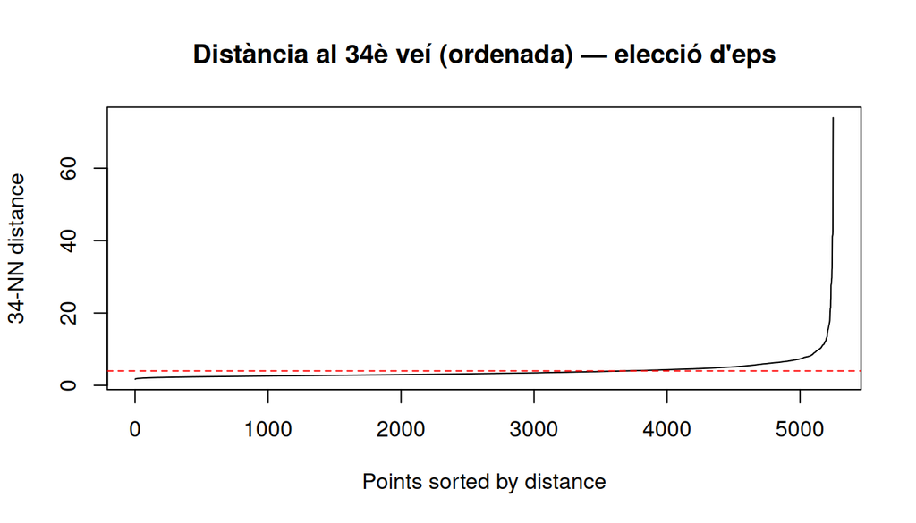

```r
kNNdistplot(Xs, k = 34)
abline(h = 4, col = "red", lty = 2)   # eps escollit al colze
title("Distància al 34è veí (ordenada) — elecció d'eps")
```

El colze se situa al voltant de **`eps = 4`**. Ajustem *DBSCAN* amb aquests valors i, en paral·lel, *OPTICS* (que no fixa `eps` sinó que ordena tots els punts per densitat i en permet extreure després l’agrupament):

```r
db <- dbscan(Xs, eps = 4, minPts = 34)
oo <- optics(Xs, minPts = 34)
xd <- extractDBSCAN(oo, eps_cl = 4)   # extracció DBSCAN a partir de l'ordre OPTICS

c(DBSCAN_clusters = length(setdiff(unique(db$cluster), 0)),
  DBSCAN_soroll_pct = round(100 * mean(db$cluster == 0), 1),
  OPTICS_clusters = length(setdiff(unique(xd$cluster), 0)),
  OPTICS_soroll_pct = round(100 * mean(xd$cluster == 0), 1))
```

```
##   DBSCAN_clusters DBSCAN_soroll_pct   OPTICS_clusters OPTICS_soroll_pct
##               1.0              16.3               1.0              16.3
```

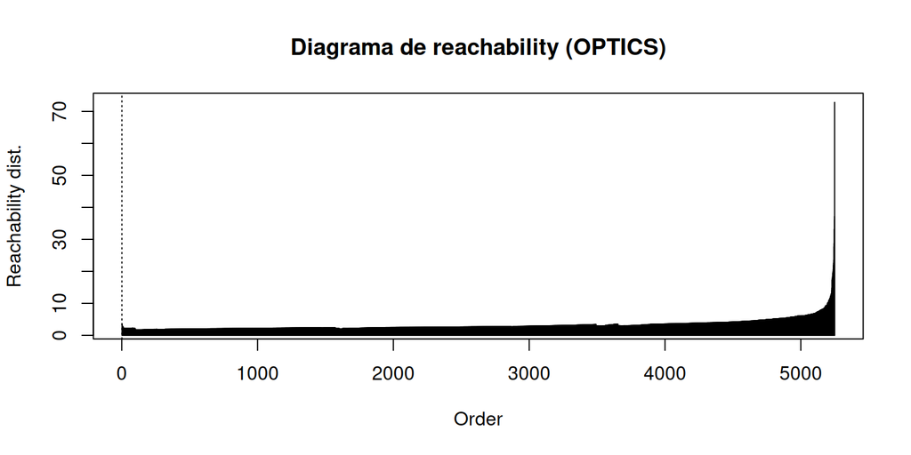

```r
plot(oo, main = "Diagrama de reachability (OPTICS)")
```

Per fer-ho més intuïtiu, projectem els pacients sobre les **dues primeres components principals** (la mateixa projecció PCA de l’exercici 1) i els acolorim segons si DBSCAN els assigna al clúster dens o al soroll:

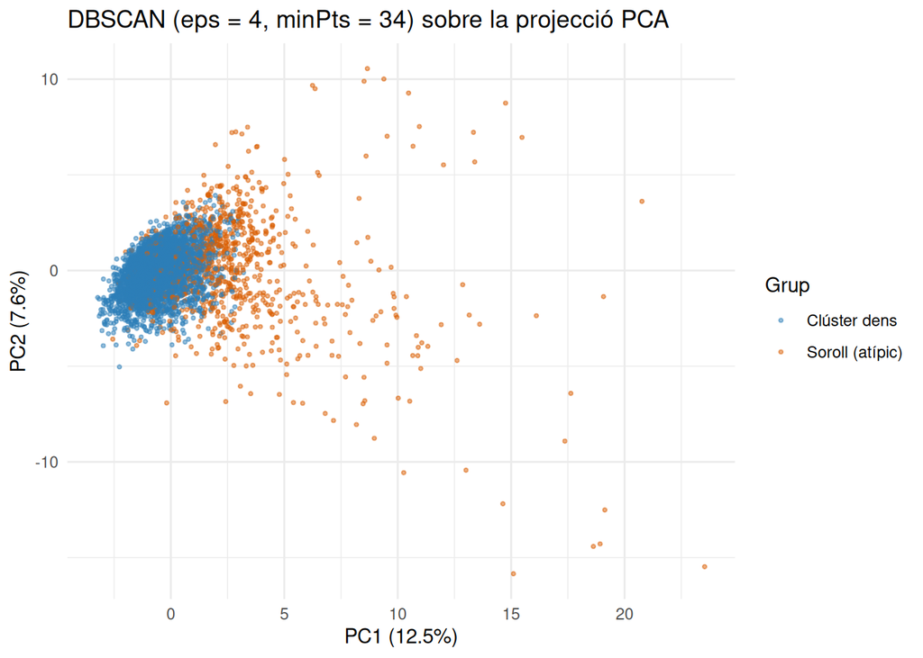

```r
pca    <- prcomp(Xs)
var_pc <- round(100 * (pca$sdev^2)[1:2] / sum(pca$sdev^2), 1)
df_pca <- data.frame(
  PC1  = pca$x[, 1], PC2 = pca$x[, 2],
  Grup = factor(ifelse(db$cluster == 0, "Soroll (atípic)", "Clúster dens"),
                levels = c("Clúster dens", "Soroll (atípic)"))
)
ggplot(df_pca, aes(PC1, PC2, color = Grup)) +
  geom_point(size = 0.7, alpha = 0.5) +
  scale_color_manual(values = c("Clúster dens"    = "#2c7fb8",
                                "Soroll (atípic)" = "#d95f02")) +
  labs(title = "DBSCAN (eps = 4, minPts = 34) sobre la projecció PCA",
       x = paste0("PC1 (", var_pc[1], "%)"),
       y = paste0("PC2 (", var_pc[2], "%)")) +
  theme_minimal()
```

### 2.6.2 S’analitzen, es descriuen i s’interpreten els resultats obtinguts amb diferents valors d’`eps` i `minPts`.

Com que el resultat de DBSCAN és molt sensible als paràmetres, fem un **escombrat** de `eps` × `minPts` i en reportem el nombre de clústers i el percentatge de soroll:

```r
escombrat <- expand.grid(minPts = c(34, 66), eps = c(3, 4, 5, 6, 7))
escombrat <- cbind(escombrat, t(mapply(function(mp, e) {
  cl <- dbscan(Xs, eps = e, minPts = mp)$cluster
  c(clusters = length(setdiff(unique(cl), 0)), soroll_pct = round(100 * mean(cl == 0), 1))
}, escombrat$minPts, escombrat$eps)))
escombrat
```

```
##    minPts eps clusters soroll_pct
## 1      34   3        3       36.4
## 2      66   3        1       41.8
## 3      34   4        1       16.3
## 4      66   4        1       18.0
## 5      34   5        1        8.9
## 6      66   5        1        9.4
## 7      34   6        1        5.2
## 8      66   6        1        5.6
## 9      34   7        1        2.6
## 10     66   7        1        3.0
```

### 2.6.3 S’obté una mesura de com és de bo l’agrupament.

El coeficient de **silueta no és aplicable** aquí en sentit estricte: requereix com a mínim dos clústers i, a la solució retinguda, DBSCAN només en forma un. La mesura de qualitat natural en aquest cas és la **proporció de soroll** (16,3 %) juntament amb el **nombre de clústers** (1). La lectura conjunta és clara: DBSCAN **no troba una estructura de grups múltiples** en aquestes dades; identifica un únic nucli dens i tracta la resta com a anomalies. Aquest és, en si mateix, el veredicte de qualitat: l’agrupament basat en densitat **no és l’eina adequada** per particionar aquesta cohort.

### 2.6.4 Es comparen els resultats obtinguts amb els models k-means i k-medians. Per exemple, analitzar si el nombre de grups coincideix i si les seves característiques són similars.

```r
table(ex1_kmeans   = km_std$cluster, DBSCAN = db$cluster)   # 0 = soroll
```

```
##           DBSCAN
## ex1_kmeans    0    1
##          1  600   85
##          2  257 4307
```

```r
table(ex2_kmedians = grup_kmed,      DBSCAN = db$cluster)
```

```
##             DBSCAN
## ex2_kmedians    0    1
##            1  405  143
##            2  452 4249
```

El **nombre de grups no coincideix** (1 + soroll, enfront dels 2 d’ex 1–2), però la relació és molt reveladora. El soroll de DBSCAN **no és aleatori**: es concentra aclaparadorament en el grup d’**alt risc**. Concretament, el **87,6 %** dels pacients d’alt risc de l’exercici 1 (600 de 685) queden marcats com a soroll, davant de només el **5,6 %** dels pacients estàndard. El clúster dens únic de DBSCAN és, en essència, **el mateix grup estàndard** que aïllaven *k-means* i *k-medians*.

### 2.6.5 Descrivim els grups en funció de les mitjanes de les variables utilitzades en l’algorisme.

Comparem el perfil mitjà (en escala original) del **clúster dens** i del **soroll**:

```r
grup_db <- factor(ifelse(db$cluster == 0, "Soroll", "Clúster dens"),
                  levels = c("Clúster dens", "Soroll"))
destacades_db <- c("age", "asa", "emop", "preop_htn", "preop_hb", "preop_alb",
                   "preop_cr", "intraop_rbc", "intraop_crystalloid")
round(t(aggregate(X[destacades_db], list(Grup = grup_db), mean)[, -1]), 2)
```

```
##                       [,1]    [,2]
## age                  57.82   56.25
## asa                   1.74    2.40
## emop                  0.06    0.36
## preop_htn             0.29    0.44
## preop_hb             13.12   11.35
## preop_alb             4.16    3.58
## preop_cr              0.81    2.51
## intraop_rbc           0.02    2.93
## intraop_crystalloid 846.05 2089.89
```

- **Clúster dens (4.392 casos) — pacient estàndard.** *ASA* ≈ 1,74, poca cirurgia urgent (`emop` ≈ 0,06), analítica normal (Hb ≈ 13,1, albúmina ≈ 4,2, creatinina ≈ 0,8) i poca transfusió. És el nucli homogeni i compacte de la cohort.
- **Soroll (857 casos) — pacient atípic / d’alt risc.** *ASA* ≈ 2,40, molta més cirurgia urgent (`emop` ≈ 0,36), anèmia (Hb ≈ 11,4), hipoalbuminèmia (≈ 3,6), **creatinina elevada** (≈ 2,5) i transfusió alta (`intraop_rbc` ≈ 2,9). Coincideix amb el perfil d’alt risc dels exercicis 1–3, ara reinterpretat com a **anomalia**.

En conclusió, *DBSCAN* i *OPTICS* **no reprodueixen** la partició de dos grups dels mètodes anteriors —i no haurien de fer-ho, atesa la dimensionalitat i la dispersió del grup minoritari—, però **confirmen indirectament** la seva troballa principal: existeix un nucli gran i homogeni de pacients estàndard, del qual es desmarca un conjunt reduït i heterogeni de pacients d’alt risc que els mètodes de densitat classifiquen, amb lògica, com a **outliers**.

> *Documentació del paquet emprat: `dbscan` (`dbscan`, `optics`, `kNNdistplot`, `extractDBSCAN`) — https://CRAN.R-project.org/package=dbscan.*

## 2.7 Exercici 5 (5%)

Comença la part **supervisada** (exercicis 5–7). La variable a predir és **`icu_admission`** (ingrés a l’UCI, *No/Sí*), un desenllaç clínicament rellevant i amb un desequilibri moderat (**18,1 % de positius**). Es va descartar `death_inhosp` (només 0,8 % positius, massa desequilibrat).

### 2.7.1 Es seleccionen les mostres d’entrenament i test.

**Conjunt de predictors.** A diferència dels models de clustering —que exigien variables quantitatives o binàries i casos complets—, els **arbres de decisió** (exercicis 6–7) admeten **variables categòriques** de forma nativa i **gestionen els valors absents** mitjançant divisions *substitutes* (*surrogate splits*). Això ens permet un conjunt de predictors **més ric** i conservar **totes les 5.926 files**. Seleccionem variables conegudes **abans de la decisió d’ingrés a l’UCI** (final de la cirurgia): demografia, comorbiditats, analítica preoperatòria, curs intraoperatori i durada de la intervenció. **Excloem explícitament les fuites d’informació** (*data leakage*): `icu_days`, `los_hosp_days` i `death_inhosp` són conseqüència o posteriors a l’ingrés, i identificadors, marques de temps i variables de text lliure d’alta cardinalitat (`dx`, `opname`) o amb >20 % d’absents (gasometries, `tubesize`) no s’inclouen.

```r
num_pred <- c("age","height","weight","bmi","asa",
  "preop_hb","preop_plt","preop_pt","preop_aptt","preop_na","preop_k","preop_gluc",
  "preop_alb","preop_ast","preop_alt","preop_bun","preop_cr",
  "intraop_rbc","intraop_ffp","intraop_crystalloid","intraop_colloid","intraop_ppf",
  "intraop_mdz","intraop_ftn","intraop_rocu","intraop_vecu","intraop_eph","intraop_phe",
  "intraop_epi","intraop_ca","op_duration_min","ane_duration_min")
cat_pred <- c("sex","emop","department","optype","approach","ane_type","position",
  "preop_htn","preop_dm","preop_pft")

# Rellegim el CSV original: el `dades` de l'ex1 té emop/preop_htn/preop_dm recodificats
# a 0/1; aquí els volem com a factors No/Sí per a regles d'arbre més llegibles.
dades_sup <- read.csv("clinical_clean.csv", stringsAsFactors = FALSE)
sup <- dades_sup[, c(num_pred, cat_pred, "icu_admission")]
sup$icu_admission <- factor(sup$icu_admission, levels = c("No", "Sí"))
for (c in cat_pred) sup[[c]] <- factor(sup[[c]])

dim(sup)                                   # 5.926 casos × 43 variables (42 predictors)
```

```
## [1] 5926   43
```

```r
round(prop.table(table(sup$icu_admission)) * 100, 1)   # balanç global del target
```

```
##
##   No   Sí
## 81.9 18.1
```

**Partició estratificada.** Fem la divisió amb `caret::createDataPartition`, que mostreja de manera **estratificada** per `icu_admission`: així la proporció de positius (18,1 %) es manté **idèntica** a entrenament i test, condició important quan la classe d’interès és minoritària.

```r
set.seed(42)
idx   <- createDataPartition(sup$icu_admission, p = 0.8, list = FALSE)
train <- sup[idx, ]
test  <- sup[-idx, ]

rbind(
  Entrenament = c(n = nrow(train), table(train$icu_admission),
                  pct_Si = round(100 * mean(train$icu_admission == "Sí"), 1)),
  Test        = c(n = nrow(test),  table(test$icu_admission),
                  pct_Si = round(100 * mean(test$icu_admission == "Sí"), 1))
)
```

```
##                n   No  Sí pct_Si
## Entrenament 4742 3883 859   18.1
## Test        1184  970 214   18.1
```

La partició resultant és de **4.742 casos d’entrenament** i **1.184 de test**, amb un **18,1 % de positius a tots dos** conjunts (859 i 214 ingressos a l’UCI, respectivament).

### 2.7.2 Es justifiquen les proporcions seleccionades.

Hem triat una proporció **80 % / 20 %** per dues raons:

- **Mida del conjunt d’entrenament.** Un arbre de decisió amb poda (exercici 6) i un segon model supervisat (exercici 7) es beneficien de **com més dades millor** per estimar bé les divisions; el 80 % (4.742 casos) ofereix un entrenament ampli.
- **Fiabilitat del test.** Amb un conjunt de dades de mida moderada (≈ 5.900 casos), el 20 % de test (1.184 casos) encara conté **214 ingressos a l’UCI**, una xifra **suficient** per estimar amb precisió raonable mètriques sensibles a la classe minoritària com la **sensibilitat** (recall). Una proporció més agressiva (p. ex. 90/10) deixaria només ≈ 107 positius al test, amb estimacions més inestables.

L’**estratificació** garanteix, a més, que el test sigui representatiu de la prevalença real d’ingrés a l’UCI, de manera que les mètriques de l’exercici 6 no quedin esbiaixades per un atzar de mostreig. Aquests conjunts `train` i `test` són els que faran servir els exercicis 6 i 7.

> *Documentació del paquet emprat: `caret` (`createDataPartition`, partició estratificada) — https://CRAN.R-project.org/package=caret; guia d’usuari: https://topepo.github.io/caret/.*

## 2.8 Exercici 6 (20%)

**Nota metodològica.** A les PAC de l’assignatura es va treballar principalment amb l’algorisme **C5.0**. En aquest exercici fem servir l’arbre **CART** (`rpart`) perquè ofereix el control més **explícit sobre la poda** —el nucli d’aquest apartat, on cal comparar l’arbre amb i sense poda mitjançant el paràmetre de complexitat (`cp`) i la taula de validació creuada (`cptable`)—. Reservem el **C5.0**, el mètode vist a classe, com a model principal de l’exercici 7, on també l’enfrontem a un *random forest*. Tots dos són algorismes d’arbres de decisió; la comparació entre ells és, precisament, l’objectiu de l’exercici 7.

### 2.8.1 S’entrena l’arbre de decisió, es generen regles i se seleccionen i s’interpreten les més significatives.

Un **arbre de decisió** (CART, *Classification And Regression Tree*) classifica fent una sèrie de **preguntes binàries** encadenades sobre les variables. A cada pas, l’algorisme tria la pregunta (per exemple, *“la durada de la cirurgia és ≥ 289 min?”*) que millor **separa** els pacients que ingressen a l’UCI dels que no. La mesura de “bona separació” és la **impuresa de Gini**: un node és pur si tots els seus pacients són de la mateixa classe. L’arbre creix dividint recursivament fins que els nodes són prou purs o prou petits, i cada **fulla** final assigna una probabilitat d’ingrés.

Ajustem el creixement amb tres paràmetres (`rpart.control`):

- **`minsplit`** (20): nombre mínim de casos en un node per intentar dividir-lo.
- **`minbucket`** (7): nombre mínim de casos en una fulla.
- **`cp`** (*complexity parameter*): millora mínima que ha d’aportar una divisió per acceptar-la. El fixem a **`cp = 0`** per fer créixer un **arbre màxim** (sense restricció), que després **podarem**.

```r
set.seed(42)
arbre_full <- rpart(icu_admission ~ ., data = train, method = "class",
                    control = rpart.control(cp = 0, minsplit = 20,
                                            minbucket = 7, xval = 10))
sum(arbre_full$frame$var == "<leaf>")   # nombre de fulles de l'arbre sense podar
```

```
## [1] 96
```

L’arbre sense podar té **96 fulles**: és massa complex, memoritza el soroll del conjunt d’entrenament (*overfitting*) i és impossible d’interpretar. La **poda** busca l’arbre més petit l’error del qual, estimat per **validació creuada** (`xerror` de la taula de complexitat), sigui estadísticament equivalent al mínim. Apliquem la **regla 1-SE** (el menor arbre amb `xerror` dins d’una desviació estàndard del mínim):

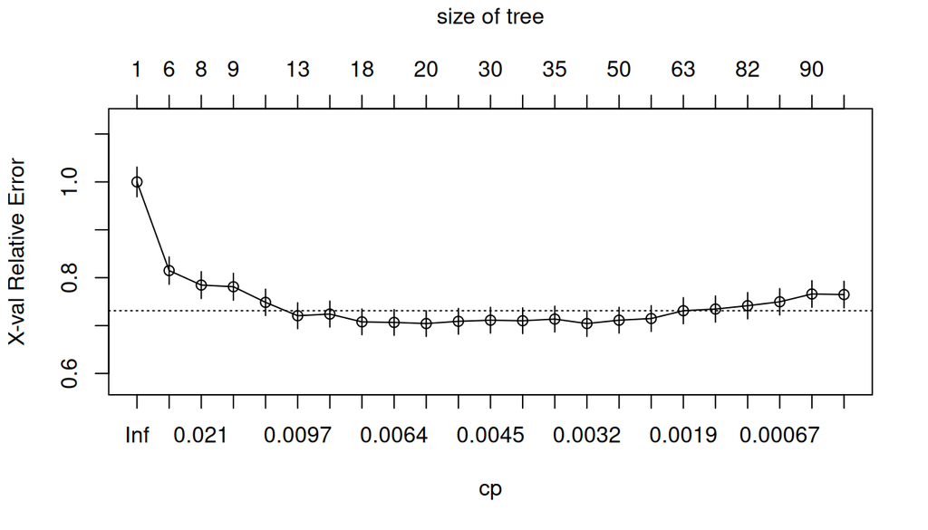

```r
plotcp(arbre_full)
```

```r
cp_tab  <- arbre_full$cptable
imin    <- which.min(cp_tab[, "xerror"])
llindar <- cp_tab[imin, "xerror"] + cp_tab[imin, "xstd"]      # mínim + 1 SE
cp_1se  <- cp_tab[which(cp_tab[, "xerror"] <= llindar)[1], "CP"]
arbre_poda <- prune(arbre_full, cp = cp_1se)
c(cp_escollit = round(cp_1se, 5),
  fulles = sum(arbre_poda$frame$var == "<leaf>"))
```

```
## cp_escollit      fulles
##     0.00815    13.00000
```

La poda redueix l’arbre de **96 a 13 fulles**: un model molt més simple i, com veurem, millor generalitzador. Les variables **més determinants** (importància de Gini) són el **tipus de cirurgia** (`optype`), el **departament**, la **durada** de la intervenció i l’anestèsia, la **posició** quirúrgica i l’**albúmina** preoperatòria:

```r
round(sort(arbre_poda$variable.importance, decreasing = TRUE)[1:8])
```

```
##              optype          department    ane_duration_min     op_duration_min
##                 226                 143                 136                 129
##            position           preop_alb intraop_crystalloid                 age
##                 123                  61                  43                  43
```

### 2.8.2 S’extreuen les regles del model en format text i gràfic.

Cada camí de l’arrel a una fulla és una **regla**. En format **gràfic**:

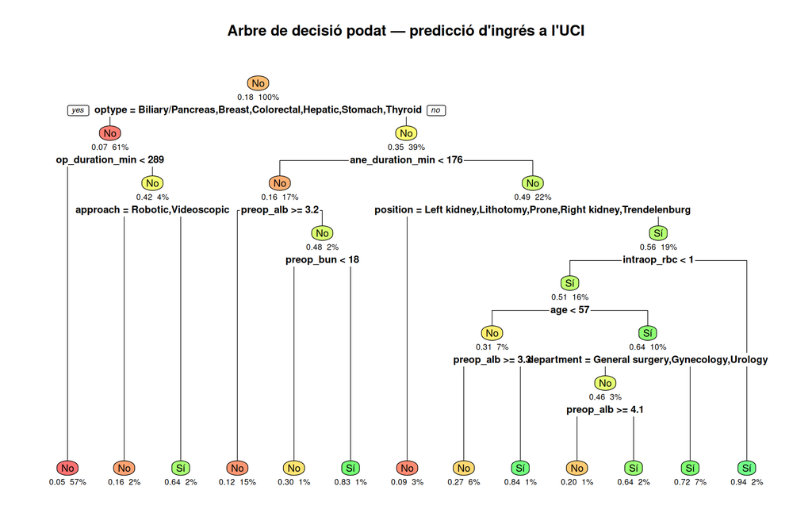

```r
rpart.plot(arbre_poda, type = 2, extra = 106, under = TRUE,
           box.palette = "RdYlGn", tweak = 1.1, fallen.leaves = TRUE,
           main = "Arbre de decisió podat — predicció d'ingrés a l'UCI")
```

Cada node mostra la **probabilitat d’ingrés a l’UCI** i el **percentatge de casos** que hi arriben. I en format **text** (probabilitat i cobertura de cada regla):

```r
rpart.rules(arbre_poda, roundint = FALSE, cover = TRUE, nn = FALSE, style = "tall")
```

```
## icu_admission is 0.05 with cover 57% when
##     optype is Biliary/Pancreas or Breast or Colorectal or Hepatic or Stomach or Thyroid
##     op_duration_min < 289
##
## icu_admission is 0.09 with cover 3% when
##     optype is Major resection or Minor resection or Others or Transplantation or Vascular
##     ane_duration_min >= 176
##     position is Left kidney or Lithotomy or Prone or Right kidney or Trendelenburg
##
## icu_admission is 0.12 with cover 15% when
##     optype is Major resection or Minor resection or Others or Transplantation or Vascular
##     ane_duration_min < 176
##     preop_alb >= 3.2
##
## icu_admission is 0.16 with cover 2% when
##     optype is Biliary/Pancreas or Breast or Colorectal or Hepatic or Stomach or Thyroid
##     op_duration_min >= 289
##     approach is Robotic or Videoscopic
##
## icu_admission is 0.20 with cover 1% when
##     optype is Major resection or Minor resection or Others or Transplantation or Vascular
##     ane_duration_min >= 176
##     position is Left lateral decubitus or Right lateral decubitus or Supine
##     preop_alb >= 4.1
##     intraop_rbc < 0.5
##     age >= 57
##     department is General surgery or Gynecology or Urology
##
## icu_admission is 0.27 with cover 6% when
##     optype is Major resection or Minor resection or Others or Transplantation or Vascular
##     ane_duration_min >= 176
##     position is Left lateral decubitus or Right lateral decubitus or Supine
##     preop_alb >= 3.3
##     intraop_rbc < 0.5
##     age < 57
##
## icu_admission is 0.30 with cover 1% when
##     optype is Major resection or Minor resection or Others or Transplantation or Vascular
##     ane_duration_min < 176
##     preop_alb < 3.2
```

[output cut: 28 more lines]

```
##     preop_bun >= 18
##
## icu_admission is 0.84 with cover 1% when
##     optype is Major resection or Minor resection or Others or Transplantation or Vascular
##     ane_duration_min >= 176
##     position is Left lateral decubitus or Right lateral decubitus or Supine
##     preop_alb < 3.3
##     intraop_rbc < 0.5
##     age < 57
##
## icu_admission is 0.94 with cover 2% when
##     optype is Major resection or Minor resection or Others or Transplantation or Vascular
##     ane_duration_min >= 176
##     position is Left lateral decubitus or Right lateral decubitus or Supine
##     intraop_rbc >= 0.5
```

### 2.8.3 Addicionalment, es genera la matriu de confusió per mesurar la capacitat predictiva de l’algorisme, tenint en compte les diferents mètriques associades a aquesta matriu (precisió, sensibilitat, especificitat…). Alternativament, si la variable objecte destudi és quantitativa pura sobtenen els criteris d’error que ens permetin determinar la capacitat predictiva.

Avaluem tots dos arbres sobre el **conjunt de test** (mai vist a l’entrenament). La classe positiva és l’ingrés a l’UCI (`Sí`):

```r
cm_full <- confusionMatrix(predict(arbre_full, test, type = "class"),
                           test$icu_admission, positive = "Sí")
cm_poda <- confusionMatrix(predict(arbre_poda, test, type = "class"),
                           test$icu_admission, positive = "Sí")

cm_poda$table   # matriu de confusió de l'arbre podat
```

```
##           Reference
## Prediction  No  Sí
##         No 915  97
##         Sí  55 117
```

```r
metr <- function(cm) round(c(
  Accuracy    = cm$overall["Accuracy"],
  Sensibilitat= cm$byClass["Sensitivity"],
  Especificitat = cm$byClass["Specificity"],
  Precisio    = cm$byClass["Pos Pred Value"],
  F1          = cm$byClass["F1"],
  Kappa       = cm$overall["Kappa"]), 3)
comparativa <- rbind(`Sense poda (96 fulles)` = metr(cm_full),
                     `Amb poda (13 fulles)`   = metr(cm_poda))
colnames(comparativa) <- c("Accuracy","Sensibilitat","Especificitat",
                           "Precisió","F1","Kappa")
comparativa
```

```
##                        Accuracy Sensibilitat Especificitat Precisió    F1 Kappa
## Sense poda (96 fulles)    0.859        0.598         0.916    0.612 0.605 0.519
## Amb poda (13 fulles)      0.872        0.547         0.943    0.680 0.606 0.531
```

Interpretació de la matriu de l’arbre podat (test, 1.184 casos): de **214 ingressos reals**, l’arbre n’encerta **117** (sensibilitat 0,55) i en falla 97; dels **970 no ingressos**, n’encerta 915 (especificitat 0,94). La **precisió** (quan diu “UCI”, quants cops encerta) és del **68 %**. L’**accuracy** global és del **87 %**, però amb classes desequilibrades aquesta xifra enganya (predir sempre “No” ja donaria 82 %); per això mirem també la **kappa** (0,53, concordança moderada per damunt de l’atzar) i el balanç sensibilitat/especificitat.

### 2.8.4 Es comparen i interpreten els resultats sense i amb opcions de poda.

La comparativa és el resultat clau de l’exercici. L’arbre **sense podar** (96 fulles) no només és inintel·ligible, sinó que **generalitza pitjor**: tot i ajustar gairebé perfectament l’entrenament, en test té **menys accuracy (0,859 vs 0,872)**, **menys precisió (0,61 vs 0,68)** i **menys kappa (0,52 vs 0,53)** que el podat. És la signatura de l’**overfitting**: les 83 fulles addicionals capturen particularitats del conjunt d’entrenament que no es repeteixen en dades noves. L’arbre **podat** sacrifica una mica de sensibilitat (0,55 vs 0,60 —detecta uns quants ingressos menys—) a canvi de ser **molt més simple, robust i interpretable**, amb una capacitat predictiva global igual o superior (F1 pràcticament idèntic, 0,606). La poda és, per tant, clarament **avantatjosa**.

**Refinament sensible al cost.** Clínicament, un **fals negatiu** (no anticipar un ingrés a l’UCI) és més greu que un fals positiu. Podem incorporar-ho amb una **matriu de pèrdua** que penalitzi més els falsos negatius, desplaçant l’arbre cap a una **sensibilitat més alta**:

```r
set.seed(42)
arbre_cost <- rpart(icu_admission ~ ., data = train, method = "class",
                    parms = list(loss = matrix(c(0, 3, 1, 0), nrow = 2)),
                    control = rpart.control(cp = 0.005))
cm_cost <- confusionMatrix(predict(arbre_cost, test, type = "class"),
                           test$icu_admission, positive = "Sí")
metr(cm_cost)
```

```
##         Accuracy.Accuracy  Sensibilitat.Sensitivity Especificitat.Specificity
##                     0.830                     0.757                     0.846
##   Precisio.Pos Pred Value                     F1.F1               Kappa.Kappa
##                     0.521                     0.617                     0.513
```

Penalitzant els falsos negatius 3:1, la **sensibilitat puja a ≈ 0,76** (detecta tres de cada quatre ingressos) a canvi de més falsos positius (especificitat ≈ 0,85). La tria entre l’arbre podat estàndard i el sensible al cost depèn de l’objectiu clínic: **cribratge** (prioritzar detectar tots els casos) o **precisió** (minimitzar falses alarmes).

### 2.8.5 Es descriuen les regles obtingudes.

Les regles són **clínicament coherents** i s’organitzen al voltant de tres eixos: el **tipus i la durada** de la cirurgia, el **departament** i la **fragilitat** preoperatòria del pacient. Les més significatives:

- **Risc molt baix (≈ 5 %, cobreix el 57 % dels casos).** Cirurgies de menor complexitat (`optype` de tiroide, mama, colorectal, biliar/pàncrees…) amb **durada < 289 min**. És la regla dominant: la majoria de pacients estàndard.
- **Risc molt alt (≈ 83 %).** Cirurgia major (resecció/trasplantament/vascular) amb **anestèsia curta** però pacient **fràgil**: albúmina baixa (< 3,2) i **urea elevada** (`preop_bun` ≥ 18) —signe de mal estat nutricional i renal—.
- **Risc alt (≈ 72 %).** Cirurgia major i llarga al **departament de cirurgia toràcica** en pacients ≥ 57 anys: la cirurgia toràcica major és, per si mateixa, un predictor potent d’ingrés a l’UCI.
- **Risc alt (≈ 64 %).** Cirurgia de complexitat intermèdia però **llarga (≥ 289 min) i per via oberta** (no robòtica ni laparoscòpica): la durada i l’abordatge obert marquen l’agressivitat real de la intervenció.

En síntesi, l’arbre aprèn que **l’ingrés a l’UCI ve determinat sobretot pel tipus, la durada i l’agressivitat de la cirurgia, modulats per la fragilitat preoperatòria del pacient** (albúmina, urea, edat) —una lògica que coincideix amb el criteri clínic real—.

> *Documentació dels paquets emprats: `rpart` (arbres de decisió CART) — https://CRAN.R-project.org/package=rpart; `rpart.plot` (visualització i extracció de regles) — https://CRAN.R-project.org/package=rpart.plot; `caret` (matriu de confusió i mètriques) — https://CRAN.R-project.org/package=caret.*

## 2.9 Exercici 7 (10%)

### 2.9.1 Es prova amb un altre tipus d’arbre de decisió (per exemple, un criteri de partició diferent) o amb un altre tipus d’algorisme supervisat.

Provem **dos** models supervisats alternatius a l’arbre CART de l’exercici 6, que exploren dues direccions diferents:

1. **C5.0** — un altre algorisme d’arbres de decisió que fa servir un **criteri de partició diferent**: en lloc de la impuresa de Gini, divideix maximitzant el **guany d’informació** (entropia). A més, permet *boosting* (combinar molts arbres seqüencials).
2. **Random Forest** — un **algorisme d’una família diferent** (*ensemble*): en lloc d’un sol arbre, combina centenars d’arbres construïts sobre mostres aleatòries de dades i variables, i vota. Sol ser molt més precís, a canvi de perdre interpretabilitat.

**C5.0.** L’algorisme C5.0 té un detall tècnic: la seva implementació en C no tradueix bé els nivells de factor amb accents. Per evitar-ho, fem una còpia on el nivell `Sí` es reanomena a `Si` (ASCII), només per a aquest model:

```r
ascii <- function(df) {
  for (col in c("icu_admission", "emop", "preop_htn", "preop_dm")) {
    l <- levels(df[[col]]); l[l == "Sí"] <- "Si"; levels(df[[col]]) <- l
  }
  df
}
train_c <- ascii(train); test_c <- ascii(test)

set.seed(42)
c5  <- C5.0(icu_admission ~ ., data = train_c)                # arbre C5.0
c5b <- C5.0(icu_admission ~ ., data = train_c, trials = 10)   # amb boosting (10 arbres)
c5$size                                                       # nombre de fulles
```

```
## [1] 80
```

**Random Forest.** A diferència dels arbres `rpart`/C5.0, `randomForest` **no gestiona els valors absents**; els hem d’**imputar** abans (per mediana/moda, amb `na.roughfix`). Construïm un bosc de 500 arbres:

```r
train_i <- na.roughfix(train); test_i <- na.roughfix(test)
set.seed(42)
rf <- randomForest(icu_admission ~ ., data = train_i, ntree = 500, importance = TRUE)
rf$err.rate[500, "OOB"]            # error *out-of-bag* (validació interna del bosc)
```

```
##      OOB
## 0.108604
```

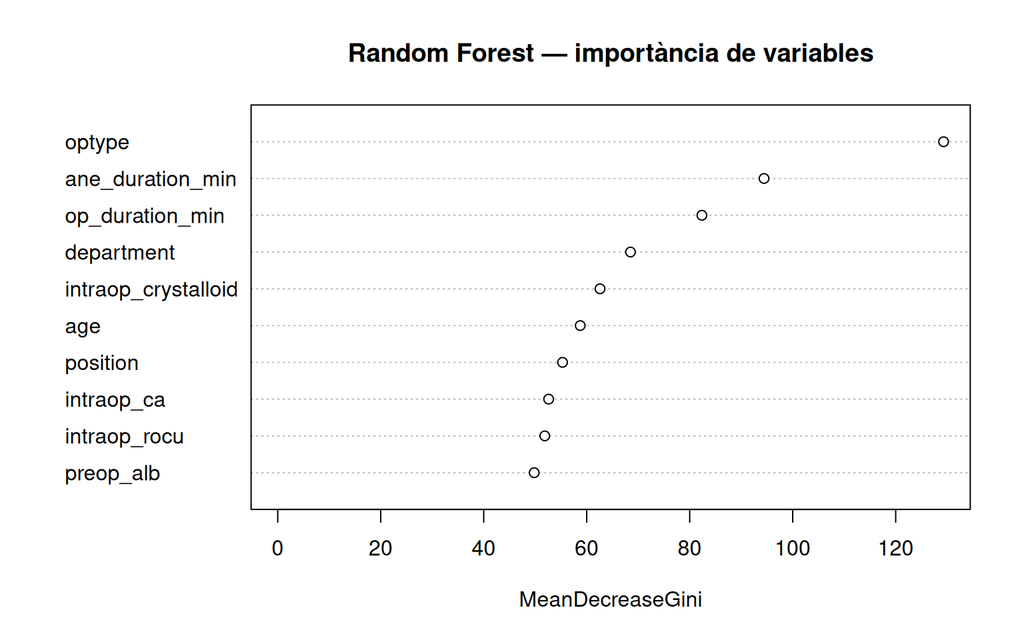

```r
varImpPlot(rf, type = 2, n.var = 10, main = "Random Forest — importància de variables")
```

### 2.9.2 Es detalla, comenta i avalua la qualitat de classificació o de l’ajust.

Avaluem tots dos models (i les seves variants) sobre el mateix conjunt de **test**:

```r
metr <- function(pred, real, pos) {
  cm <- confusionMatrix(pred, real, positive = pos)
  round(c(Accuracy = cm$overall["Accuracy"], Sensibilitat = cm$byClass["Sensitivity"],
          Especificitat = cm$byClass["Specificity"], Precisió = cm$byClass["Pos Pred Value"],
          F1 = cm$byClass["F1"], Kappa = cm$overall["Kappa"]), 3)
}
res_ex7 <- rbind(
  `C5.0 (arbre)`        = metr(predict(c5,  test_c), test_c$icu_admission, "Si"),
  `C5.0 (boosting x10)` = metr(predict(c5b, test_c), test_c$icu_admission, "Si"),
  `Random Forest (500)` = metr(predict(rf,  test_i), test_i$icu_admission, "Sí")
)
colnames(res_ex7) <- c("Accuracy","Sensibilitat","Especificitat","Precisió","F1","Kappa")
res_ex7
```

```
##                     Accuracy Sensibilitat Especificitat Precisió    F1 Kappa
## C5.0 (arbre)           0.872        0.603         0.931    0.658 0.629 0.552
## C5.0 (boosting x10)    0.894        0.603         0.959    0.763 0.674 0.612
## Random Forest (500)    0.905        0.621         0.967    0.806 0.702 0.646
```

El **C5.0** (arbre individual) ja millora lleugerament l’arbre de l’exercici 6 en sensibilitat (0,60 vs 0,55) i kappa (0,55 vs 0,53), tot mantenint l’accuracy (0,87). El **boosting** fa un salt clar (accuracy 0,89, F1 0,67), i el **Random Forest** és el millor de tots: **accuracy 0,91, precisió 0,81, F1 0,70 i kappa 0,65**, amb un error *out-of-bag* de només l’11 %. El bosc identifica, a més, **les mateixes variables clau** que l’arbre CART (tipus de cirurgia, durades, departament, edat), cosa que **reforça la validesa** de la història clínica trobada a l’exercici 6.

### 2.9.3 Es comparen els resultats amb el mètode supervisat de l’exercici 6.

```r
arbre6 <- metr(predict(arbre_poda, test, type = "class"), test$icu_admission, "Sí")
rbind(`Ex6: arbre CART podat` = arbre6, res_ex7)
```

```
##                       Accuracy.Accuracy Sensibilitat.Sensitivity
## Ex6: arbre CART podat             0.872                    0.547
## C5.0 (arbre)                      0.872                    0.603
## C5.0 (boosting x10)               0.894                    0.603
## Random Forest (500)               0.905                    0.621
##                       Especificitat.Specificity Precisió.Pos Pred Value F1.F1
## Ex6: arbre CART podat                     0.943                   0.680 0.606
## C5.0 (arbre)                              0.931                   0.658 0.629
## C5.0 (boosting x10)                       0.959                   0.763 0.674
## Random Forest (500)                       0.967                   0.806 0.702
##                       Kappa.Kappa
## Ex6: arbre CART podat       0.531
## C5.0 (arbre)                0.552
## C5.0 (boosting x10)         0.612
## Random Forest (500)         0.646
```

La comparativa global il·lustra el **compromís fonamental entre capacitat predictiva i interpretabilitat**:

- **Arbre CART podat (ex 6)** — el **menys precís** (kappa 0,53), però el **més interpretable**: 13 regles llegibles que un clínic pot validar i aplicar a mà.
- **C5.0** — encara és un arbre (interpretable, tot i ser més gran), amb un criteri d’entropia que aquí captura una mica millor la classe minoritària.
- **C5.0 amb boosting i Random Forest** — els **més precisos** (kappa 0,61 i 0,65), però **caixes negres**: són desenes o centenars d’arbres combinats i ja no es poden llegir com un conjunt de regles; només n’obtenim la *importància de variables*.

La tria del model depèn, doncs, de l’objectiu. Si calgués una eina **explicable** per donar suport a la decisió clínica a peu de llit, l’**arbre podat** és preferible malgrat la seva precisió més modesta. Si l’objectiu fos **maximitzar l’encert** predictiu (per exemple, per a una alerta automàtica de risc), el **Random Forest** seria la millor opció. En tots els casos, la **coincidència de les variables més importants** entre tots els models confirma que el senyal predictiu (tipus, durada i agressivitat de la cirurgia, més la fragilitat del pacient) és **robust i real**, no un artefacte d’un algorisme concret.

> *Documentació dels paquets emprats: `C50` (arbres C5.0 i* boosting*) — https://CRAN.R-project.org/package=C50; guia: https://topepo.github.io/C5.0/; `randomForest` (boscos aleatoris) — https://CRAN.R-project.org/package=randomForest; `caret` (matriu de confusió) — https://CRAN.R-project.org/package=caret.*

## 2.10 Exercici 8 (10%)

### 2.10.1 S’identifica quines possibles limitacions tenen les dades que heu seleccionat per obtenir conclusions amb els models (supervisat i no supervisat).

**Limitacions comunes a tots els models.** El joc de dades prové de **VitalDB**, un registre d’un **únic centre** (Seoul National University Hospital). Això limita la **validesa externa**: els patrons trobats reflecteixen la pràctica clínica i la població d’aquell hospital i poden no generalitzar a altres sistemes sanitaris, poblacions o èpoques. A més, és una **fotografia transversal**: no hi ha seguiment temporal ni informació de causalitat, de manera que tots els models capturen **associacions, no relacions causa-efecte**. Hi ha també una proporció elevada de **valors absents** —les gasometries preoperatòries superen el 90 %, `intraop_ebl` i `intraop_uo` ronden el 40 %—, que ens va obligar a **descartar variables potencialment informatives** (llindar del 20 %).

**Limitacions específiques dels models no supervisats (ex 1–4).** L’agrupament només podia emprar variables **quantitatives o binàries** i **casos complets** (5.249 de 5.926), de manera que es va **perdre la informació categòrica** (tipus de cirurgia, departament…) que després va resultar clau en els models supervisats. L’estructura en 33 dimensions és més un **gradient** que no pas grups ben separats: ho reflecteixen la silueta baixa (0,37) i la escassa variància explicada (`betweenss/totss` ≈ 0,07). Per tant, la partició en dos grups és **útil però difusa**, i la mateixa dimensionalitat va fer **fracassar** els mètodes de densitat (exercici 4). Les etiquetes “alt risc/estàndard” són **construccions derivades de les dades**, no categories clíniques validades.

**Limitacions específiques dels models supervisats (ex 5–7).** La variable objectiu està **desequilibrada** (18 % de positius), cosa que esbiaixa els models cap a la classe majoritària i fa enganyosa l’*accuracy*. Diverses variables predictores són **intraoperatòries**: encara que es coneixen abans de la decisió d’ingrés, la frontera amb una possible **fuita d’informació** és estreta i cal interpretar-les amb cautela. Finalment, el *random forest* va requerir **imputar** els absents (mediana/moda), una simplificació que introdueix supòsits propis.

### 2.10.2 S’identifiquen possibles riscos de l’ús del model i se’n resumeixen les principals conclusions (mínim 300 paraules).

**Riscos de l’ús dels models.** El primer risc és **confondre associació amb causalitat**: que la durada de la cirurgia o el tipus d’intervenció prediguin l’ingrés a l’UCI **no** vol dir que modificar-los eviti l’ingrés; usar el model per guiar decisions com si fos causal seria un error. El segon és la **manca de generalització**: un model entrenat en un sol hospital pot **degradar-se** notablement en una població diferent (*distribution shift*), i desplegar-lo sense revalidar seria arriscat. El tercer afecta especialment els **falsos negatius**: amb una sensibilitat de l’ordre de 0,55 (arbre podat), el model **deixa escapar gairebé la meitat** dels ingressos reals; en un context clínic, no anticipar un ingrés a l’UCI és greu, motiu pel qual vam proposar la variant **sensible al cost**. El quart és la **interpretabilitat**: el *random forest*, tot i ser el més precís, és una **caixa negra**; confiar-hi cegament fomenta l’**automation bias** (acceptar la predicció sense criteri) i dificulta retre comptes d’una decisió. Finalment, hi ha un risc d’**equitat**: si certs subgrups de pacients estan infrarepresentats, el model pot rendir pitjor per a ells sense que ho detectem.

**Conclusions principals.** Aquest treball ha aplicat, sobre una cohort quirúrgica real, tot l’espectre de tècniques de mineria de dades, supervisades i no supervisades, amb resultats **coherents entre si i clínicament plausibles**. Pel costat **no supervisat**, *k-means* i *k-medians* coincideixen (concordança del 92 %) a separar dos perfils: un **pacient quirúrgic complex/fràgil** (≈ 13 %) i un **pacient estàndard** (≈ 87 %). La mètrica del cosinus va aportar una lectura complementària, reorganitzant la cohort per **comorbiditat crònica i edat** en lloc de severitat aguda, i els mètodes de densitat (DBSCAN/OPTICS) van confirmar indirectament l’estructura en reinterpretar els pacients d’alt risc, molt dispersos, com a *outliers* —una conclusió internament consistent amb la major dispersió d’aquell grup ja observada a l’exercici 1—. Pel costat **supervisat**, l’ingrés a l’UCI és **predictible amb una qualitat moderada-bona**: el *random forest* assoleix una *accuracy* del 91 % i una *kappa* de 0,65, per damunt de l’arbre CART podat (87 %, *kappa* 0,53). El resultat més rellevant, però, no és cap xifra concreta sinó la **convergència**: els quatre models supervisats identifiquen **les mateixes variables determinants** —tipus, durada i agressivitat de la cirurgia, departament i fragilitat preoperatòria del pacient (albúmina, urea, edat)—, cosa que indica que el senyal predictiu és **robust i real**. Tot plegat indica un compromís entre **precisió i interpretabilitat**: l’arbre de decisió ofereix regles llegibles i auditables a costa d’una mica de precisió, mentre que els *ensembles* maximitzen l’encert a costa de la transparència. La tria final hauria de dependre de l’**objectiu d’ús** —suport explicable a peu de llit o alerta automàtica— i, en qualsevol cas, exigiria una **validació externa** abans de qualsevol aplicació real. Més enllà dels resultats concrets, el projecte il·lustra una lliçó metodològica de fons: **cap algorisme és intrínsecament “el millor”**. Cada mètode incorpora supòsits propis —la mètrica de distància en el cas no supervisat, el criteri de partició o el grau d’ensemblat en el supervisat— que determinen què és capaç de “veure” a les dades. Per això la **triangulació** de diverses tècniques, més que l’optimització d’una de sola, ha estat el que ha permès distingir el **senyal robust** (la influència del tipus i la durada de la cirurgia, i de la fragilitat del pacient) del **soroll metodològic**, i és la pràctica que recomanaríem mantenir en qualsevol anàlisi posterior d’aquesta mena de dades clíniques.

## 2.11 Interacció amb la IA (5%)

### 2.11.1 Realitzar almenys 3 consultes tenint en compte el que s’ha proposat al punt 9 de l’enunciat.

Durant el desenvolupament de la pràctica he fet servir una eina d’IA generativa com a **suport tècnic i metodològic**, sempre verificant-ne les respostes amb la documentació oficial i amb proves sobre les meves pròpies dades. A continuació documento les consultes més rellevants, classificades en les cinc categories. El gros del suport s’ha concentrat en la **programació en R**, mentre que la **interpretació clínica** dels resultats l’he treballada de manera conjunta, aportant-hi el criteri propi.

#### 2.11.1.1 Consulta 1 — Programació

1. **Pregunta.** *“Com puc implementar un k-medians «pur» a R, amb la mediana com a centre i distància Manhattan? És el mateix que la funció `pam()`?”*
2. **Resposta obtinguda.** L’IA va aclarir que `pam()` implementa *around medoids* (el centre és un cas real, no la mediana) i va recomanar el paquet `flexclust`, concretament `kcca(..., family = kccaFamily("kmedians"))`, per a un k-medians amb centroides–mediana i mètrica L1.
3. **Decisió.** Vaig adoptar `flexclust` com a mètode principal de l’exercici 2 i vaig conservar `pam()` com a comparació opcional *around medoids*, tal com permet l’enunciat.
4. **Reflexió crítica.** La distinció medoide vs. mediana no em quedava clara i la resposta la va fixar bé. Tot i així, no la vaig donar per bona sense més: vaig comprovar empíricament que els dos mètodes donaven particions diferents (PAM divergeix força) i que el k-medians concordava en un 92 % amb el k-means, cosa que en va justificar la tria.

#### 2.11.1.2 Consulta 2 — Programació

1. **Pregunta.** *“En entrenar un model C5.0 obtinc l’error `unable to translate 'Sí' to a wide string`. Com el soluciono?”*
2. **Resposta obtinguda.** L’IA va identificar que la implementació en C de `C50` no gestiona bé els **nivells de factor amb accents** segons la configuració regional, i va proposar dues vies: ajustar el *locale* o **recodificar els nivells a ASCII**.
3. **Decisió.** Vaig crear una còpia del conjunt on el nivell `Sí` es reanomena a `Si` **només per al model C5.0**, mantenint `Sí` a la resta del document.
4. **Reflexió crítica.** Vaig descartar la via del *locale* després de comprovar que `read.csv(encoding = "UTF-8")` no resolia el problema; la recodificació ASCII va ser la solució robusta. Aprenentatge: alguns paquets antics basats en C no són compatibles amb cadenes UTF-8, un detall fàcil de passar per alt treballant en català.

#### 2.11.1.3 Consulta 3 — Programació

1. **Pregunta.** *“El `randomForest` falla amb les meves dades, que tenen valors absents. Com ho gestiono, si abans amb `rpart` no calia fer res?”*
2. **Resposta obtinguda.** L’IA va explicar que, a diferència de `rpart` i `C5.0` —que tracten els NA amb divisions substitutes—, `randomForest` **necessita dades completes**, i va suggerir imputar amb `na.roughfix()` (mediana per a numèriques, moda per a categòriques) o bé `rfImpute()`.
3. **Decisió.** Vaig imputar amb `na.roughfix()` el conjunt d’entrenament i el de test abans d’ajustar i predir amb el bosc.
4. **Reflexió crítica.** Sóc conscient que imputar el test amb les seves pròpies medianes és una simplificació amb un cert risc de fuita; per a aquesta pràctica és acceptable, però en un entorn real caldria imputar el test amb els estadístics apresos a l’entrenament. La consulta em va ajudar a entendre **per què** uns models toleren els NA i altres no.

#### 2.11.1.4 Consulta 4 — Diagnosi

1. **Pregunta.** *“El DBSCAN em retorna sempre un sol clúster i molt soroll, provi els valors de `eps` i `minPts` que provi. És un error meu?”*
2. **Resposta obtinguda.** L’IA va explicar que **no necessàriament és un error**: en espais de molta dimensió (33 variables) la densitat es torna gairebé uniforme i DBSCAN té dificultats per formar grups (*maledicció de la dimensionalitat*). Va recomanar el `kNNdistplot` per orientar `eps` i interpretar el resultat com a informació en si mateix.
3. **Decisió.** Vaig mantenir el resultat, vaig fer un escombrat sistemàtic de paràmetres i vaig interpretar el soroll com un conjunt d’*outliers*.
4. **Reflexió crítica.** El que semblava un fracàs tècnic va resultar ser una troballa: ho vaig confirmar creuant els punts de soroll amb el grup d’alt risc de l’exercici 1 (coincidien en gran part). Em va ensenyar a no descartar un resultat “lleig” sense entendre’n la causa.

#### 2.11.1.5 Consulta 5 — Interpretació

1. **Pregunta.** *“Amb un 18 % de positius, el meu arbre té un 87 % d’accuracy. És bo? Quines mètriques he de mirar de debò?”*
2. **Resposta obtinguda.** L’IA va advertir de la **paradoxa de l’exactitud** (predir sempre «No» ja donaria un 82 %) i va recomanar fixar-se en la **kappa**, la **sensibilitat** i l’**especificitat**, i considerar el **cost asimètric** dels errors.
3. **Decisió.** Vaig reportar la matriu de confusió amb totes les mètriques i vaig prioritzar la *kappa* i el balanç sensibilitat/especificitat per damunt de l’*accuracy*.
4. **Reflexió crítica.** L’IA va proporcionar el **marc de mètriques**, però la lectura clínica —que un fals negatiu (no anticipar un ingrés a l’UCI) és més greu que un fals positiu— la vam desenvolupar de manera conjunta, i és la que va motivar el refinament sensible al cost. Aquí l’aportació pròpia de criteri va ser decisiva.